# Practical 1

In this practical session, we begin to explore some of the concepts covered in the lectures and give you the opportunity to run some code.

Practical 1 focuses on building a logistic regression model and highlights some key steps and decisions that are needed when developing a logistic prediction model.

We will begin by loading our data set and perform some integrity checks. Some exploratory analysis will then be conducted to gain an understanding of the data. Once we are happy and familiar with the data we begin by showing you how to conduct univariate logistic regression models for categorical predictor variables. Following this we will explore univariate regression with a continuous variable and how to decide if the association between the dependent and independent variable is linear or non-linear. Finally, we will build a multivariable prediction model.

## The data

For todays practicals we will be using data from the Second Manifestations of ARTerial disease (SMART) study  
Here is a [link](https://link.springer.com/article/10.1023/A:1007621514757) to more information about the study.

| Variable | Description |
| --- | --- |
| TEVENT | Time of event (days) |
| EVENT | Cardiovascular event (0=no, 1=yes) |
| outcome | Cardiovascular event within 2 years of study entry (0=no, 1=yes) |
| SEX | 1 = male, 2 = female |
| AGE | Age (years) |
| DIABETES | Ever diabetes (0=no, 1=yes) |
| CEREBRAL | Ever cerebrovascular disease (0=no, 1=yes) |
| CARDIAC | Ever cardiovascular disease (0=no, 1=yes) |
| AAA | Ever abdominal aortic aneurysm (0=no, 1=yes) |
| PERIPH | Ever periferal aortic aneurysm (0=no, 1=yes) |
| STENOSIS | Ever periferal vascular disease (0=no, 1=yes) |
| SYSTBP | Systolic blood pressure (automatic, mm Hg) |
| DIASTBP | Diastolic blood pressure (automatic, mm Hg) |
| SYSTH | Systolic blood pressure (by hand, mm Hg) |
| DIASTH | Diastolic blood pressure (by hand, mm Hg) |
| LENGTHO | Height (m) |
| WEIGHTO | Weight (kg) |
| BMIO | Body mass index ($kg/m^2$) |
| CHOLO | Cholesterol level (mmol/L) |
| albumin | Albumin in urine (1=no, 2=low, 3=high) |
| SMOKING | Smoking status (1=no, 2=Former, 3=current) |
| packsyrs | Packetyears smoked |
| alcohol | Alcohol consumption (1=no, 2=Former, 3=current) |

The data was made freely available by Ewout Steyerberg who used the SMART data in his book 'Clinical prediction models: A Practical Approach to Development, Validation and Updating'. The data set is available from http://http://www.clinicalpredictionmodels.org/ but has been formated to make them easier for you to use.

## Lets begin

First lets load the packages we will be using in the practical

```r
#install.packages("ggplot2")
```

```r
library(ggplot2)
library(plyr)
library(rms)
library(MASS)
library(reshape)
library(lmtest)
```

## Part 1 load and clean the data

Load the data and perform some data checks

The data is saved as an R data set (rds file), for information on how to load excel files please see the Intro to R HTML.

```r
smart <- readRDS(file= "SMARTs_P1.rds")
class(smart) # This tells us the class/data type of the object smart (hopefully returning data.frame)
dim(smart)
sapply(smart,class) # This tells us the class of each variable in the smart data, eg, categorical='factor' or continuous='numeric'
```

'data.frame'

1. 3873

2. 23

**TEVENT**

'numeric'

**EVENT**

'integer'

**SEX**

'factor'

**AGE**

'integer'

**DIABETES**

'factor'

**CEREBRAL**

'factor'

**CARDIAC**

'factor'

**AAA**

'factor'

**PERIPH**

'factor'

**STENOSIS**

'factor'

**SYSTBP**

'integer'

**DIASTBP**

'integer'

**SYSTH**

'integer'

**DIASTH**

'integer'

**LENGTHO**

'numeric'

**WEIGHTO**

'integer'

**BMIO**

'numeric'

**CHOLO**

'numeric'

**albumin**

'integer'

**SMOKING**

'factor'

**packyrs**

'numeric'

**alcohol**

'factor'

**outcome**

'integer'

Albumin is not a factor variable so we need to change and label

```r
# Albumin
smart$albumin <- as.factor(smart$albumin)
levels(smart$albumin)
smart$albumin <- revalue(smart$albumin, c("1"="No", "2"="Low", "3"="High"))
levels(smart$albumin)
```

1. '1'

2. '2'

3. '3'

1. 'No'

2. 'Low'

3. 'High'

There are 2 variables for systolic blood pressure (SBP) because it can either done by hand or automatic. If we check, we can see there is a lot of missing data in both of the SBP variables.

```r
table(is.na(smart$SYSTBP)==FALSE)
table(is.na(smart$SYSTH)==FALSE)
```

```
FALSE  TRUE
 1223  2650
```

```
FALSE  TRUE
 1498  2375
```

However, if we look at how many individuals have SBP recorded by atleast one of the methods we find all but 3 have atleast one SBP measurement.

```r
table(is.na(smart$SYSTH)==FALSE | is.na(smart$SYSTBP)==FALSE)
```

```
FALSE  TRUE
    3  3870
```

We can combine both of these variables to create a new SBP variable, such that, the variable will use the automatic SBP reading for each individual unless it is missing and then it will replace the missing indicator with the SBP recorded by hand.

```r
smart$SBP <- ifelse(is.na(smart$SYSTBP)==FALSE, smart$SYSTBP, smart$SYSTH)
table(is.na(smart$SBP))
```

```
FALSE  TRUE
 3870     3
```

Can you look at the diastolic blood pressure and the other variables?

## Part 2 Exploratory analysis

Now the data has been 'cleaned' we can begin to provide overviews of the data see the number of events/outcomes in our data.

```r
# Overview of the data
attach(smart)
dim(smart)
summary(smart)
sapply(smart,class)
describe(smart)

# Summarise outcome
table(outcome)
round(prop.table(table(outcome))*100,0)
```

1. 3873

2. 24

```
     TEVENT           EVENT            SEX            AGE        DIABETES
 Min.   :   0.1   Min.   :0.0000   Female: 976   Min.   :19.00   0   :2987
 1st Qu.: 555.0   1st Qu.:0.0000   Male  :2897   1st Qu.:52.00   1   : 846
 Median :1213.0   Median :0.0000                 Median :60.00   NA's:  40
 Mean   :1370.3   Mean   :0.1188                 Mean   :59.56
 3rd Qu.:2165.0   3rd Qu.:0.0000                 3rd Qu.:68.00
 Max.   :3466.0   Max.   :1.0000                 Max.   :82.00

 CEREBRAL CARDIAC  AAA      PERIPH   STENOSIS        SYSTBP
 0:2726   0:1713   0:3457   0:2933   0   :3058   Min.   : 96.0
 1:1147   1:2160   1: 416   1: 940   1   : 722   1st Qu.:127.0
                                     NA's:  93   Median :139.0
                                                 Mean   :141.3
                                                 3rd Qu.:154.0
                                                 Max.   :216.0
                                                 NA's   :1223
    DIASTBP          SYSTH           DIASTH          LENGTHO
 Min.   : 46.0   Min.   : 79.0   Min.   : 45.00   Min.   :1.42
 1st Qu.: 73.0   1st Qu.:126.0   1st Qu.: 75.00   1st Qu.:1.68
 Median : 79.0   Median :140.0   Median : 82.00   Median :1.75
 Mean   : 79.7   Mean   :142.2   Mean   : 82.44   Mean   :1.74
 3rd Qu.: 86.0   3rd Qu.:156.0   3rd Qu.: 90.00   3rd Qu.:1.80
 Max.   :127.0   Max.   :244.0   Max.   :136.00   Max.   :2.05
 NA's   :1221    NA's   :1498    NA's   :1499     NA's   :1
    WEIGHTO            BMIO           CHOLO        albumin        SMOKING
 Min.   : 37.00   Min.   :15.43   Min.   : 2.200   No  :2897   Current: 444
 1st Qu.: 72.00   1st Qu.:24.11   1st Qu.: 4.400   Low : 655   Former :2711
 Median : 80.00   Median :26.30   Median : 5.100   High: 114   Never  : 693
 Mean   : 81.01   Mean   :26.70   Mean   : 5.196   NA's: 207   NA's   :  25
 3rd Qu.: 89.00   3rd Qu.:28.73   3rd Qu.: 5.900
 Max.   :143.00   Max.   :48.85   Max.   :20.900
 NA's   :2        NA's   :3       NA's   :18
    packyrs          alcohol        outcome             SBP
 Min.   :  0.00   Current:2689   Min.   :0.00000   Min.   : 79
 1st Qu.:  5.90   Former : 408   1st Qu.:0.00000   1st Qu.:127
 Median : 19.50   Never  : 751   Median :0.00000   Median :140
 Mean   : 22.62   NA's   :  25   Mean   :0.05474   Mean   :142
 3rd Qu.: 34.20                  3rd Qu.:0.00000   3rd Qu.:154
 Max.   :120.00                  Max.   :1.00000   Max.   :242
 NA's   :21                                        NA's   :3
```

**TEVENT**

'numeric'

**EVENT**

'integer'

**SEX**

'factor'

**AGE**

'integer'

**DIABETES**

'factor'

**CEREBRAL**

'factor'

**CARDIAC**

'factor'

**AAA**

'factor'

**PERIPH**

'factor'

**STENOSIS**

'factor'

**SYSTBP**

'integer'

**DIASTBP**

'integer'

**SYSTH**

'integer'

**DIASTH**

'integer'

**LENGTHO**

'numeric'

**WEIGHTO**

'integer'

**BMIO**

'numeric'

**CHOLO**

'numeric'

**albumin**

'factor'

**SMOKING**

'factor'

**packyrs**

'numeric'

**alcohol**

'factor'

**outcome**

'integer'

**SBP**

'integer'

```
smart

 24  Variables      3873  Observations
--------------------------------------------------------------------------------
TEVENT
       n  missing distinct     Info     Mean      Gmd      .05      .10
    3873        0     1934        1     1370     1078     98.6    197.0
     .25      .50      .75      .90      .95
   555.0   1213.0   2165.0   2762.4   3017.4

lowest :    0.1    1.0    2.0    3.0    4.0, highest: 3451.0 3452.0 3463.0 3465.0 3466.0
--------------------------------------------------------------------------------
EVENT
       n  missing distinct     Info      Sum     Mean      Gmd
    3873        0        2    0.314      460   0.1188   0.2094

--------------------------------------------------------------------------------
SEX
       n  missing distinct
    3873        0        2

Value      Female   Male
Frequency     976   2897
Proportion  0.252  0.748
--------------------------------------------------------------------------------
AGE
       n  missing distinct     Info     Mean      Gmd      .05      .10
    3873        0       62    0.999    59.56    11.94       41       46
     .25      .50      .75      .90      .95
      52       60       68       73       76

lowest : 19 20 23 24 25, highest: 78 79 80 81 82
--------------------------------------------------------------------------------
DIABETES
       n  missing distinct
    3833       40        2

Value          0     1
Frequency   2987   846
Proportion 0.779 0.221
```

[output cut: 135 more lines]

```
Proportion   0.699   0.106   0.195
--------------------------------------------------------------------------------
outcome
       n  missing distinct     Info      Sum     Mean      Gmd
    3873        0        2    0.155      212  0.05474   0.1035

--------------------------------------------------------------------------------
SBP
       n  missing distinct     Info     Mean      Gmd      .05      .10
    3870        3      125        1      142    23.06      112      117
     .25      .50      .75      .90      .95
     127      140      154      170      180

lowest :  79  94  95  96  97, highest: 216 218 222 223 242
--------------------------------------------------------------------------------
```

```
outcome
   0    1
3661  212
```

```
outcome
 0  1
95  5
```

We see that 212 (5%) individuals have the outcome of interest.  
It can be useful to also summarise each variable by the outcome

```r
# Summarise categorical variables by outcome
table(SEX,outcome) # Produces a table of counts
round(prop.table(table(SEX,outcome),2)*100,0) # Produces a table of percentages
round(prop.table(table(outcome,SEX),2)*100,0) # Produces a table of percentages

table(SMOKING,outcome)
round(prop.table(table(SMOKING,outcome),2)*100,0)
round(prop.table(table(outcome,SMOKING),2)*100,0)
```

```
        outcome
SEX         0    1
  Female  933   43
  Male   2728  169
```

```
        outcome
SEX       0  1
  Female 25 20
  Male   75 80
```

```
       SEX
outcome Female Male
      0     96   94
      1      4    6
```

```
         outcome
SMOKING      0    1
  Current  423   21
  Former  2562  149
  Never    654   39
```

```
         outcome
SMOKING    0  1
  Current 12 10
  Former  70 71
  Never   18 19
```

```
       SMOKING
outcome Current Former Never
      0      95     95    94
      1       5      5     6
```

```
   Min. 1st Qu.  Median    Mean 3rd Qu.    Max.    NA's
  15.43   24.11   26.30   26.70   28.73   48.85       3
```

```
Warning message:
"Removed 3 rows containing non-finite values (stat_bin)."`stat_bin()` using `bins = 30`. Pick better value with `binwidth`.
Warning message:
"Removed 3 rows containing non-finite values (stat_bin)."
```

[figure not shown]

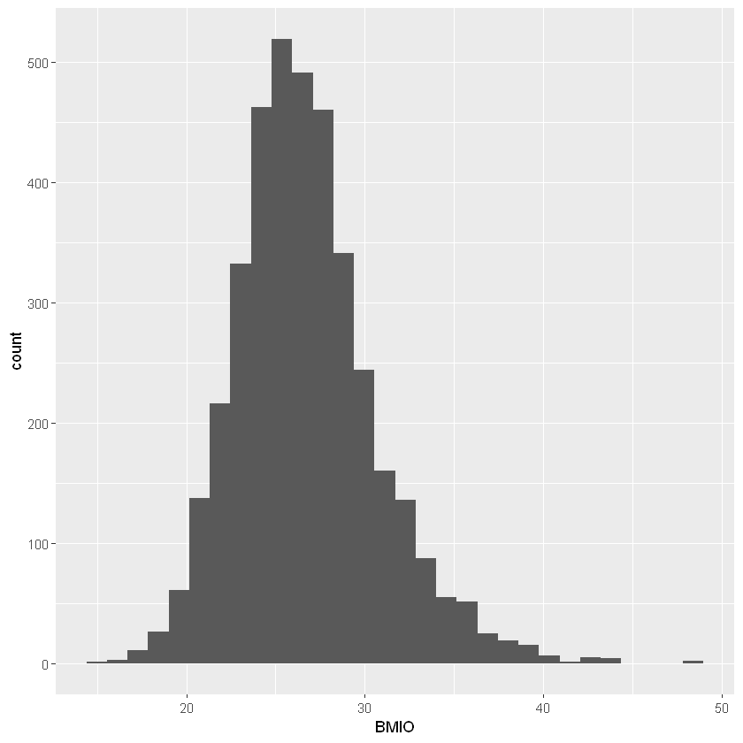

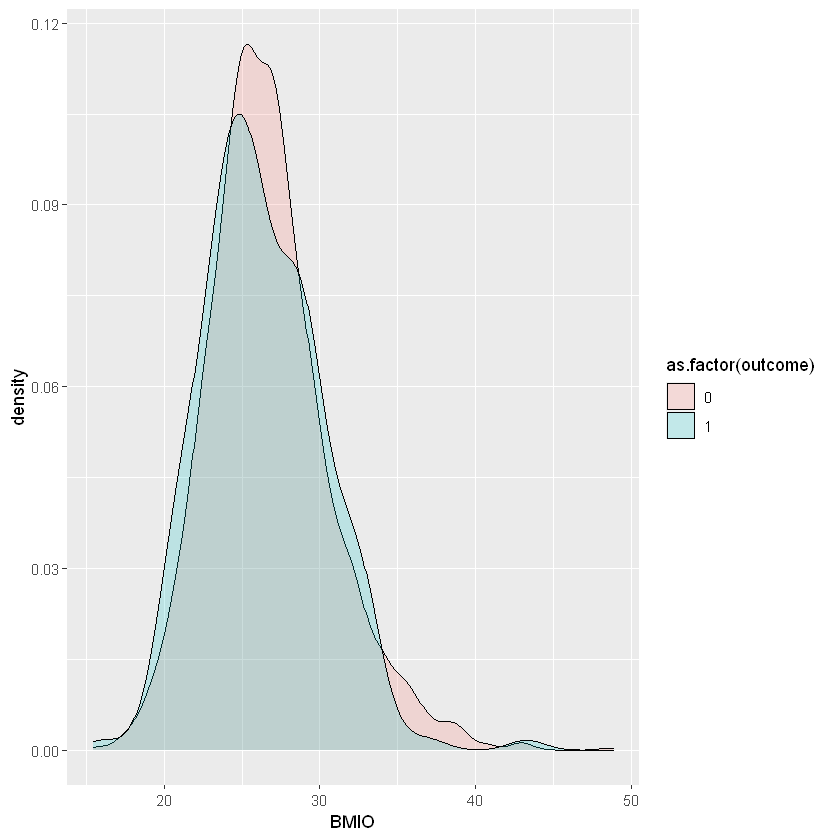

```r
# Look at distributions of continuous variables
summary(BMIO)
ggplot(smart,aes(x=BMIO))+geom_histogram()+facet_grid(~outcome)+theme_light()+ labs(title = "Histogram of age split by outcome")
ggplot(smart, aes(BMIO, fill = outcome)) + geom_histogram()
ggplot(smart, aes(BMIO, fill = as.factor(outcome))) + geom_density(alpha = 0.2)
```

### Question - Above we look into BMI, can you do the same for age?

What is the range of age values?  
Plot histogram of age  
Plot the density of age by outcome

```
   Min. 1st Qu.  Median    Mean 3rd Qu.    Max.
  19.00   52.00   60.00   59.56   68.00   82.00
```

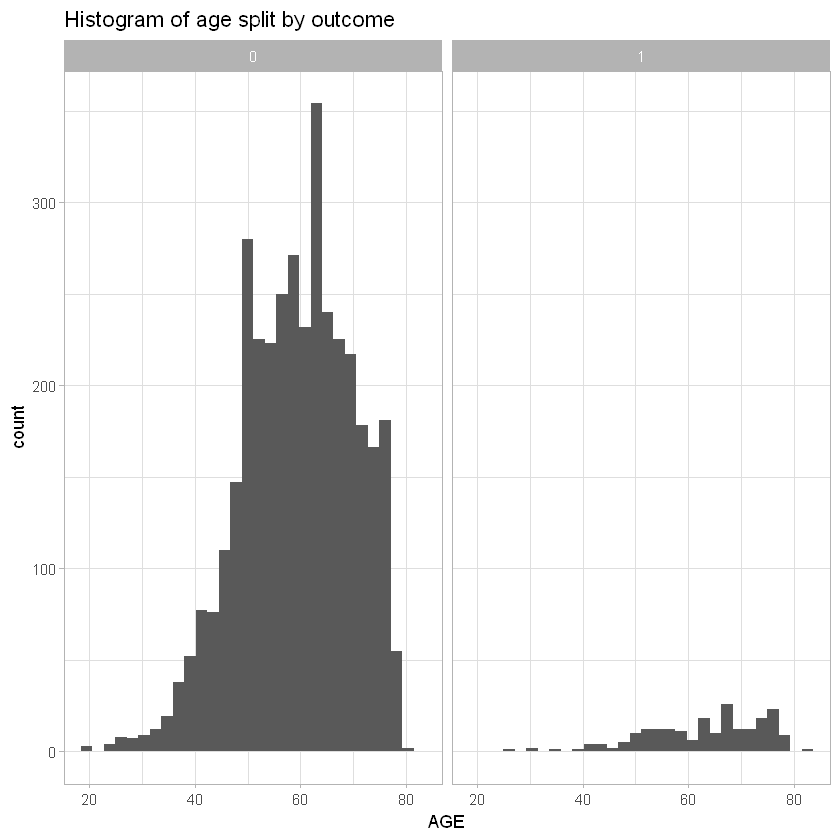

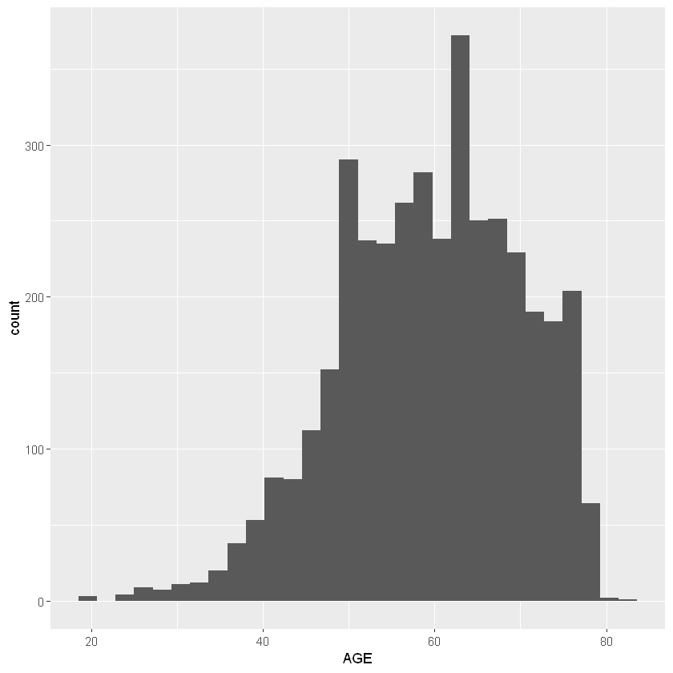

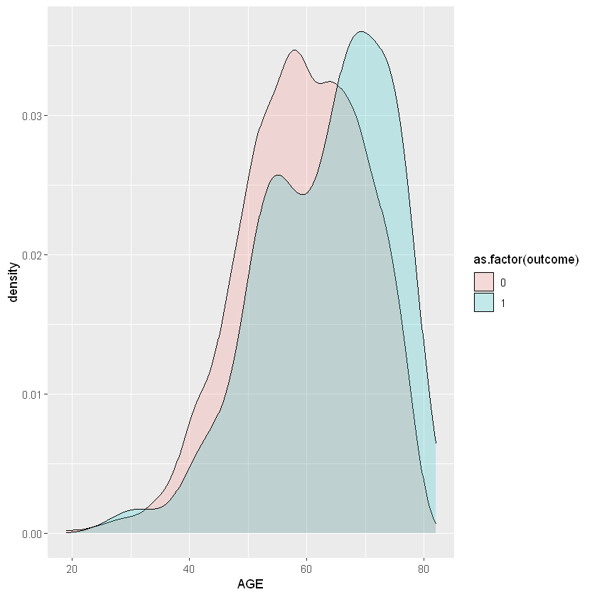

```r
# Insert R code here
summary(AGE)
ggplot(smart,aes(x=AGE))+geom_histogram()+facet_grid(~outcome)+theme_light()+ labs(title = "Histogram of age split by outcome")
ggplot(smart, aes(AGE, fill = outcome)) + geom_histogram()
ggplot(smart, aes(AGE, fill = as.factor(outcome))) + geom_density(alpha = 0.2)
```

## Part 3 Univariate logistic regression with categorical variables

Lets start by producing a univariate logistic model with gender as the independant variable.

```r
detach(smart)
# Univariable models for categorical variables

# Recode SEX so that the baseline is male #
smart$SEX2 = relevel(smart$SEX, ref="Male")
attach(smart)

# logistic regression model including sex as the only independent variable
sex_mod <- glm(outcome~SEX2,family="binomial")
summary(sex_mod)
beta <- round(exp(sex_mod$coef),3) # extract the model coefficients from the model
b <- round(exp(confint.default(sex_mod)),3) # Compute the confidence intervals for the model coefficients
d <- cbind(beta,b)
d
```

```
Call:
glm(formula = outcome ~ SEX2, family = "binomial")

Deviance Residuals:
    Min       1Q   Median       3Q      Max
-0.3467  -0.3467  -0.3467  -0.3002   2.4989

Coefficients:
            Estimate Std. Error z value Pr(>|z|)
(Intercept) -2.78143    0.07927 -35.088   <2e-16 ***
SEX2Female  -0.29578    0.17494  -1.691   0.0909 .
---
Signif. codes:  0 '***' 0.001 '**' 0.01 '*' 0.05 '.' 0.1 ' ' 1

(Dispersion parameter for binomial family taken to be 1)

    Null deviance: 1644  on 3872  degrees of freedom
Residual deviance: 1641  on 3871  degrees of freedom
AIC: 1645

Number of Fisher Scoring iterations: 5
```

|  | beta | 2.5 % | 97.5 % |
| --- | --- | --- | --- |
| (Intercept) | 0.062 | 0.053 | 0.072 |
| SEX2Female | 0.744 | 0.528 | 1.048 |

```r
summary(sex_mod)
```

```
Call:
glm(formula = outcome ~ SEX2, family = "binomial")

Deviance Residuals:
    Min       1Q   Median       3Q      Max
-0.3467  -0.3467  -0.3467  -0.3002   2.4989

Coefficients:
            Estimate Std. Error z value Pr(>|z|)
(Intercept) -2.78143    0.07927 -35.088   <2e-16 ***
SEX2Female  -0.29578    0.17494  -1.691   0.0909 .
---
Signif. codes:  0 '***' 0.001 '**' 0.01 '*' 0.05 '.' 0.1 ' ' 1

(Dispersion parameter for binomial family taken to be 1)

    Null deviance: 1644  on 3872  degrees of freedom
Residual deviance: 1641  on 3871  degrees of freedom
AIC: 1645

Number of Fisher Scoring iterations: 5
```

```r
beta <- round(exp(sex_mod$coef),3) # extract the model coefficients from the model
beta
```

**(Intercept)**

0.062

**SEX2Female**

0.744

Can you interpret the output?

The estimate is the log odds.

**By modifying the code above, try fitting a logistic regression model to the SMART data with albumin as the predictor.**  
**Q. Interpret the output. Is albumin a significant predictor? What level of albumin is associated with the lowest risk?**

```r
# Insert R code here
a_mod <- glm(outcome~albumin,family="binomial")
summary(a_mod)
beta <- round(exp(a_mod$coef),3) # extract the model coefficients from the model
b <- round(exp(confint.default(a_mod)),3) # Compute the confidence intervals for the model coefficients
d <- cbind(beta,b)
d
```

```
Call:
glm(formula = outcome ~ albumin, family = "binomial")

Deviance Residuals:
    Min       1Q   Median       3Q      Max
-0.5312  -0.3006  -0.3006  -0.3006   2.4978

Coefficients:
            Estimate Std. Error z value Pr(>|z|)
(Intercept)  -3.0742     0.0904 -34.008  < 2e-16 ***
albuminLow    0.5592     0.1739   3.216   0.0013 **
albuminHigh   1.1871     0.2914   4.073 4.63e-05 ***
---
Signif. codes:  0 '***' 0.001 '**' 0.01 '*' 0.05 '.' 0.1 ' ' 1

(Dispersion parameter for binomial family taken to be 1)

    Null deviance: 1506.3  on 3665  degrees of freedom
Residual deviance: 1485.9  on 3663  degrees of freedom
  (207 observations deleted due to missingness)
AIC: 1491.9

Number of Fisher Scoring iterations: 5
```

|  | beta | 2.5 % | 97.5 % |
| --- | --- | --- | --- |
| (Intercept) | 0.046 | 0.039 | 0.055 |
| albuminLow | 1.749 | 1.244 | 2.459 |
| albuminHigh | 3.278 | 1.851 | 5.803 |

## Part 4 Univariate logistic regression with continuous variables

Now lets try with a continuous variable (AGE).

```r
# Assuming age is linear
age_mod <- glm(outcome~AGE,family="binomial")
summary(age_mod)
exp(confint.default((age_mod))) # if you want confidence intervals for the model coefficients
exp(0.03763)
```

```
Call:
glm(formula = outcome ~ AGE, family = "binomial")

Deviance Residuals:
    Min       1Q   Median       3Q      Max
-0.4787  -0.3721  -0.3215  -0.2775   2.8832

Coefficients:
            Estimate Std. Error z value Pr(>|z|)
(Intercept) -5.15648    0.46657 -11.052  < 2e-16 ***
AGE          0.03763    0.00732   5.141 2.74e-07 ***
---
Signif. codes:  0 '***' 0.001 '**' 0.01 '*' 0.05 '.' 0.1 ' ' 1

(Dispersion parameter for binomial family taken to be 1)

    Null deviance: 1644.0  on 3872  degrees of freedom
Residual deviance: 1615.8  on 3871  degrees of freedom
AIC: 1619.8

Number of Fisher Scoring iterations: 6
```

|  | 2.5 % | 97.5 % |
| --- | --- | --- |
| (Intercept) | 0.002308999 | 0.01437844 |
| AGE | 1.023553684 | 1.05334708 |

1.03834697341472

If you wanted to calculate the models average predicted risk for a 40 year old, or an 80 year old, you can do this using the code below.

```r
lp40 <- predict(age_mod,data.frame(AGE=40))
risk40 <- exp(lp40)/(1+exp(lp40))

lp80 <- predict(age_mod,data.frame(AGE=80))
risk80 <- exp(lp80)/(1+exp(lp80))


matrix(c("risk40","risk80", risk40, risk80),ncol=2,byrow=F)
```

| risk40 | 0.0252977615539029 |
| --- | --- |
| risk80 | 0.10467289852795 |

We see that on average, a 40 year old individual has a 2.5% risk of a cardiovascular event within 2 years.  
Alternatively, you can also use this code to obtain the risk for an individual who is 40 years old. The results are the same, it is just another way to calculate the risk.

```r
risk40a <- predict(age_mod,data.frame(AGE=40), type="response")*100
# 'type="response"' gives the predicted probabilites and so multiply by 100 to get the risk as a percentage
risk40b <- 1/(1+exp(-lp40))*100 # alternative calculation
c(risk40a, risk40b)
```

**1**

2.52977615539029

**1**

2.52977615539029

## Part 5 Modelling a continuos variable using splines

Lets model age using splines. For information on splines, see Elements of stratistical learning book chapter 5.

Splines allow us to model non-linear relationships. They are piesewise polynomials, such that, polynomials are fit at different intervals along the variable of interest which is defined by pre-detewrmined points, knows as knots.

Lets first create spline variables using the rcs command. We run the command rcs(AGE,n), where n refers to the number of knots. This will result in n-1 terms in the model output. For example, rcs(AGE,3) transforms age into a spline with 3 knots (automatically placed at the minimum, maximum and median age values) and 2 age terms.

Lets consiuder 3 different spline choices for age...

```r
age3_spline <- rcs(AGE,3)
age4_spline <- rcs(AGE,4)
age5_spline <- rcs(AGE,5)
```

Fit a logistic regression model using each set of spline variables & predict the linear predictor (LP)

```r
age3_mod <- glm(outcome~age3_spline,family="binomial")
summary(age3_mod)
```

```
Call:
glm(formula = outcome ~ age3_spline, family = "binomial")

Deviance Residuals:
    Min       1Q   Median       3Q      Max
-0.5799  -0.3549  -0.2908  -0.2776   2.5644

Coefficients:
                 Estimate Std. Error z value Pr(>|z|)
(Intercept)     -3.014784   0.826820  -3.646 0.000266 ***
age3_splineAGE  -0.004786   0.015779  -0.303 0.761646
age3_splineAGE'  0.051368   0.017975   2.858 0.004267 **
---
Signif. codes:  0 '***' 0.001 '**' 0.01 '*' 0.05 '.' 0.1 ' ' 1

(Dispersion parameter for binomial family taken to be 1)

    Null deviance: 1644.0  on 3872  degrees of freedom
Residual deviance: 1608.2  on 3870  degrees of freedom
AIC: 1614.2

Number of Fisher Scoring iterations: 6
```

```r
lp_age1 <- predict(age_mod)

age3_mod <- glm(outcome~age3_spline,family="binomial")
age3_mod
lp_age3 <- predict(age3_mod)

age4_mod <- glm(outcome~age4_spline,family="binomial")
age4_mod
lp_age4 <- predict(age4_mod)

age5_mod <- glm(outcome~age5_spline,family="binomial")
age5_mod
lp_age5 <- predict(age5_mod)
```

```
Call:  glm(formula = outcome ~ age3_spline, family = "binomial")

Coefficients:
    (Intercept)   age3_splineAGE  age3_splineAGE'
      -3.014784        -0.004786         0.051368

Degrees of Freedom: 3872 Total (i.e. Null);  3870 Residual
Null Deviance:	    1644
Residual Deviance: 1608 	AIC: 1614
```

```
Call:  glm(formula = outcome ~ age4_spline, family = "binomial")

Coefficients:
     (Intercept)    age4_splineAGE   age4_splineAGE'  age4_splineAGE''
       -3.439183          0.004632          0.010750          0.158339

Degrees of Freedom: 3872 Total (i.e. Null);  3869 Residual
Null Deviance:	    1644
Residual Deviance: 1608 	AIC: 1616
```

```
Call:  glm(formula = outcome ~ age5_spline, family = "binomial")

Coefficients:
      (Intercept)     age5_splineAGE    age5_splineAGE'   age5_splineAGE''
         -3.76956            0.01277           -0.04864            0.45158
age5_splineAGE'''
         -0.63407

Degrees of Freedom: 3872 Total (i.e. Null);  3868 Residual
Null Deviance:	    1644
Residual Deviance: 1607 	AIC: 1617
```

It is dificult to interpret output when using splines and easier to visualise.

Lets plot all LPs together for visual inspection (including the linear model)

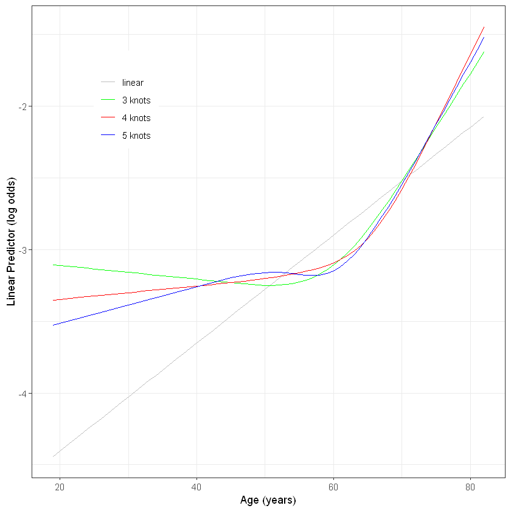

```r
data_part6 <- data.frame(AGE,lp_age1,lp_age3,lp_age4,lp_age5)
data_part6_m <- melt(data_part6,id.vars='AGE')
plot_part6 <- ggplot(data_part6_m,aes(AGE,value,colour=variable))+geom_line()+scale_colour_manual(labels=c("linear","3 knots","4 knots","5 knots"),values=c("gray","green","red","blue"))+theme_bw()
plot_part6 + labs(x="Age (years)",y="Linear Predictor (log odds)",color="") + theme(legend.position=c(0.2,0.8))
```

From this graph which term would you use to model age? Do you think age is linear?  
We can check which is the best fitted model and most appropriate term to use for age by comparing AIC or BIC

Note, AIC is a measure of in sample prediction error that incorporates the goodness of fit and complexity of the model.

Both AIC and BIC are penalised-likelihood criteria, but BIC penalises model complexity more than AIC.

AIC = 2k - 2log(likelihood)

```r
summary(age_mod)
```

```
Call:
glm(formula = outcome ~ AGE, family = "binomial")

Deviance Residuals:
    Min       1Q   Median       3Q      Max
-0.4787  -0.3721  -0.3215  -0.2775   2.8832

Coefficients:
            Estimate Std. Error z value Pr(>|z|)
(Intercept) -5.15648    0.46657 -11.052  < 2e-16 ***
AGE          0.03763    0.00732   5.141 2.74e-07 ***
---
Signif. codes:  0 '***' 0.001 '**' 0.01 '*' 0.05 '.' 0.1 ' ' 1

(Dispersion parameter for binomial family taken to be 1)

    Null deviance: 1644.0  on 3872  degrees of freedom
Residual deviance: 1615.8  on 3871  degrees of freedom
AIC: 1619.8

Number of Fisher Scoring iterations: 6
```

```r
age_spline_check <- matrix(c(AIC(age_mod),
         BIC(age_mod),
         AIC(age3_mod),
         BIC(age3_mod),
         AIC(age4_mod),
         BIC(age4_mod),
         AIC(age5_mod),
         BIC(age5_mod)), ncol=2, byrow=TRUE)

colnames(age_spline_check) <- c("AIC", "BIC")
rownames(age_spline_check) <- c("age_mod","age3_mod", "age4_mod", "age5_mod")
age_spline_check
```

|  | AIC | BIC |
| --- | --- | --- |
| age_mod | 1619.782 | 1632.306 |
| age3_mod | 1614.187 | 1632.972 |
| age4_mod | 1615.562 | 1640.609 |
| age5_mod | 1617.404 | 1648.713 |

From the AIC we would conclude age should be a non-linear term with three knots.

As well as AIC and BIC, you could also perform a likelihood ratio test. This performs a statistical test to compare the godness of fit between two nested models. See spline chapter in elements of statistical learning book for an example (chapter 5, p146)

**Question - Using the above example, is there a non-linear relationship between BMI and the outcome? What term would you** **choose to model BMI? Do you think this makes sense biologically?**

```
Call:  glm(formula = outcome ~ bmi3_spline, family = "binomial")

Coefficients:
     (Intercept)   bmi3_splineBMIO  bmi3_splineBMIO'
        -1.67895          -0.04614           0.02681

Degrees of Freedom: 3869 Total (i.e. Null);  3867 Residual
  (3 observations deleted due to missingness)
Null Deviance:	    1644
Residual Deviance: 1641 	AIC: 1647
```

```
Call:  glm(formula = outcome ~ bmi4_spline, family = "binomial")

Coefficients:
      (Intercept)    bmi4_splineBMIO   bmi4_splineBMIO'  bmi4_splineBMIO''
         -0.63329           -0.09475            0.28107           -0.93902

Degrees of Freedom: 3869 Total (i.e. Null);  3866 Residual
  (3 observations deleted due to missingness)
Null Deviance:	    1644
Residual Deviance: 1640 	AIC: 1648
```

```
Call:  glm(formula = outcome ~ bmi5_spline, family = "binomial")

Coefficients:
       (Intercept)     bmi5_splineBMIO    bmi5_splineBMIO'   bmi5_splineBMIO''
          -3.26466             0.03099            -1.13997             7.58204
bmi5_splineBMIO'''
         -12.15171

Degrees of Freedom: 3869 Total (i.e. Null);  3865 Residual
  (3 observations deleted due to missingness)
Null Deviance:	    1644
Residual Deviance: 1635 	AIC: 1645
```

|  | AIC | BIC |
| --- | --- | --- |
| bmi_mod | 1645.445 | 1657.967 |
| bmi3_mod | 1647.189 | 1665.972 |
| bmi4_mod | 1648.332 | 1673.376 |
| bmi5_mod | 1644.674 | 1675.979 |

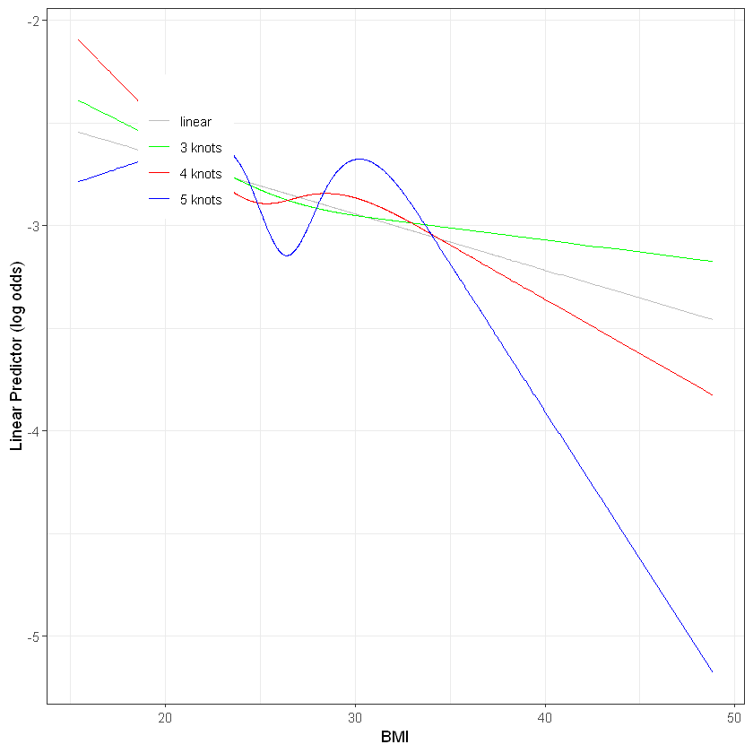

```r
# Insert R code here
bmi3_spline <- rcs(BMIO,3)
bmi4_spline <- rcs(BMIO,4)
bmi5_spline <- rcs(BMIO,5)

bmi_mod <- glm(outcome~BMIO,family="binomial")
lp_bmi1 <- predict(bmi_mod)

bmi3_mod <- glm(outcome~bmi3_spline,family="binomial")
bmi3_mod
lp_bmi3 <- predict(bmi3_mod)

bmi4_mod <- glm(outcome~bmi4_spline,family="binomial")
bmi4_mod
lp_bmi4 <- predict(bmi4_mod)

bmi5_mod <- glm(outcome~bmi5_spline,family="binomial")
bmi5_mod
lp_bmi5 <- predict(bmi5_mod)

BMI1 <- na.omit(smart$BMIO)
data_part6 <- data.frame(BMI1,lp_bmi1,lp_bmi3,lp_bmi4,lp_bmi5)
data_part6_m <- melt(data_part6,id.vars='BMI1')
plot_part6 <- ggplot(data_part6_m,aes(BMI1,value,colour=variable))+geom_line()+scale_colour_manual(labels=c("linear","3 knots","4 knots","5 knots"),values=c("gray","green","red","blue"))+theme_bw()
plot_part6 + labs(x="BMI",y="Linear Predictor (log odds)",color="") + theme(legend.position=c(0.2,0.8))
bmi_spline_check <- matrix(c(AIC(bmi_mod),
         BIC(bmi_mod),
         AIC(bmi3_mod),
         BIC(bmi3_mod),
         AIC(bmi4_mod),
         BIC(bmi4_mod),
         AIC(bmi5_mod),
         BIC(bmi5_mod)), ncol=2, byrow=TRUE)

colnames(bmi_spline_check) <- c("AIC", "BIC")
rownames(bmi_spline_check) <- c("bmi_mod","bmi3_mod", "bmi4_mod", "bmi5_mod")
bmi_spline_check
```

## Part 5 Building a multivariable model

Now we will move beyond univariate analysis and build a model using variable selection.

We will consider the following candidate predictors for inclusion in our model:  
SEX, AGE, SBP, alcohol, CHOLO, BMIO, DIABETES, CARDIAC, SMOKING, AAA

Below we have subset the data to include only the data we need and removed any individuals with missing data.  
**Note: removing individuals with missing data has been done for simplicity and is not advised in practice. This can induce bias and one should always consider techniques such as multiple imputation if data are missing**

```r
detach(smart)
smart <- subset(smart, select = c(outcome, SEX, AGE, SBP, alcohol, CHOLO, BMIO, DIABETES, CARDIAC, SMOKING, AAA))
smart <- na.omit(smart)
age3_spline <- rcs(smart$AGE,3)
attach(smart)
```

Next we can use forward or backward selection to develop a multivariable prediction model. We can use AIC to include/exclude predictors when building a model.

**Forward selection**, involves starting with no variables in the model, testing the addition of each variable using a chosen model fit criterion, adding the variable (if any) whose inclusion gives the most statistically significant improvement of the fit, and repeating this process until none improves the model to a statistically significant extent.

**Backward selection**, involves starting with all candidate variables, testing the deletion of each variable using a chosen model fit criterion, deleting the variable (if any) whose loss gives the most statistically insignificant deterioration of the model fit, and repeating this process until no further variables can be deleted without a statistically insignificant loss of fit.

Here we willconsider AIC as our criteria for variable selection and use a p-value of 0.1 (equivalent to a 2.706 change in AIC) so not to be too stringent.

```r
k10 <- qchisq(0.10,1,lower.tail=FALSE)
k10
```

2.70554345409542

```r
#k10 <- qchisq(0.10,1,lower.tail=FALSE) # this give the change in AIC we consider to be significant in our stepwise selection

# Forward selection (by AIC)
empty_mod_2 <- glm(outcome~1,family="binomial")
forward_mod_2 <- stepAIC(empty_mod_2,k=k10,scope=list(upper=~SEX+age3_spline + SBP + alcohol + CHOLO + BMIO + DIABETES + CARDIAC + SMOKING + AAA,lower=~1),direction="forward",trace=TRUE)
```

```
Start:  AIC=1610.31
outcome ~ 1

              Df Deviance    AIC
+ age3_spline  2   1571.6 1579.7
+ AAA          1   1587.1 1592.5
+ SBP          1   1599.9 1605.3
+ DIABETES     1   1600.9 1606.3
+ SEX          1   1604.1 1609.5
+ alcohol      2   1601.8 1609.9
<none>             1607.6 1610.3
+ BMIO         1   1605.3 1610.7
+ CHOLO        1   1606.7 1612.1
+ CARDIAC      1   1607.6 1613.0
+ SMOKING      2   1607.2 1615.3

Step:  AIC=1579.7
outcome ~ age3_spline

           Df Deviance    AIC
+ AAA       1   1560.6 1571.4
+ DIABETES  1   1567.0 1577.8
+ SEX       1   1567.9 1578.7
<none>          1571.6 1579.7
+ SBP       1   1570.6 1581.4
+ BMIO      1   1570.6 1581.4
+ CHOLO     1   1570.9 1581.7
+ alcohol   2   1568.2 1581.7
+ CARDIAC   1   1571.5 1582.4
+ SMOKING   2   1571.5 1585.0

Step:  AIC=1571.4
outcome ~ age3_spline + AAA

           Df Deviance    AIC
+ DIABETES  1   1555.2 1568.7
<none>          1560.6 1571.4
+ SEX       1   1558.2 1571.7
+ SBP       1   1559.2 1572.7
+ alcohol   2   1557.1 1573.3
+ BMIO      1   1559.9 1573.5
+ CHOLO     1   1560.2 1573.7
+ CARDIAC   1   1560.2 1573.7
+ SMOKING   2   1560.6 1576.8

Step:  AIC=1568.68
outcome ~ age3_spline + AAA + DIABETES

          Df Deviance    AIC
<none>         1555.2 1568.7
+ SEX      1   1552.7 1568.9
+ BMIO     1   1553.5 1569.7
+ SBP      1   1554.2 1570.4
+ CHOLO    1   1554.6 1570.8
+ CARDIAC  1   1554.8 1571.1
+ alcohol  2   1552.4 1571.3
+ SMOKING  2   1555.1 1574.1
```

```r
summary(forward_mod_2)
```

```
Call:
glm(formula = outcome ~ age3_spline + AAA + DIABETES, family = "binomial")

Deviance Residuals:
    Min       1Q   Median       3Q      Max
-0.7975  -0.3586  -0.2855  -0.2602   2.6195

Coefficients:
                   Estimate Std. Error z value Pr(>|z|)
(Intercept)       -2.961038   0.825988  -3.585 0.000337 ***
age3_splinesmart  -0.008679   0.015795  -0.549 0.582685
age3_splinesmart'  0.049203   0.018070   2.723 0.006472 **
AAA1               0.667711   0.184992   3.609 0.000307 ***
DIABETES1          0.381083   0.159892   2.383 0.017155 *
---
Signif. codes:  0 '***' 0.001 '**' 0.01 '*' 0.05 '.' 0.1 ' ' 1

(Dispersion parameter for binomial family taken to be 1)

    Null deviance: 1607.6  on 3802  degrees of freedom
Residual deviance: 1555.2  on 3798  degrees of freedom
AIC: 1565.2

Number of Fisher Scoring iterations: 6
```

```r
exp(0.381)
```

1.46374760540973

**Can you interpret the output?**

Now lets try Backward selection.

**Can you also interpret this output?**

```r
# Backward selection (by AIC)
full_mod_2 <- glm(outcome~SEX+age3_spline + SBP + alcohol + CHOLO + BMIO + DIABETES + CARDIAC + SMOKING + AAA,family="binomial")
backward_mod_2 <- stepAIC(full_mod_2,k=k10,scope=list(upper=~SEX+age3_spline + SBP + alcohol + CHOLO + BMIO + DIABETES + CARDIAC + SMOKING + AAA,lower=~1),direction="backward",trace=TRUE)
```

```
Start:  AIC=1581.74
outcome ~ SEX + age3_spline + SBP + alcohol + CHOLO + BMIO +
    DIABETES + CARDIAC + SMOKING + AAA

              Df Deviance    AIC
- SMOKING      2   1543.9 1576.3
- CARDIAC      1   1544.5 1579.6
- CHOLO        1   1544.7 1579.9
- SBP          1   1545.0 1580.1
- alcohol      2   1548.2 1580.7
- BMIO         1   1546.1 1581.2
<none>             1543.9 1581.7
- SEX          1   1548.0 1583.2
- DIABETES     1   1549.4 1584.6
- AAA          1   1554.0 1589.2
- age3_spline  2   1560.7 1593.2

Step:  AIC=1576.34
outcome ~ SEX + age3_spline + SBP + alcohol + CHOLO + BMIO +
    DIABETES + CARDIAC + AAA

              Df Deviance    AIC
- CARDIAC      1   1544.5 1574.3
- CHOLO        1   1544.7 1574.5
- SBP          1   1545.0 1574.7
- alcohol      2   1548.4 1575.4
- BMIO         1   1546.1 1575.8
<none>             1543.9 1576.3
- SEX          1   1548.1 1577.9
- DIABETES     1   1549.4 1579.2
- AAA          1   1554.0 1583.8
- age3_spline  2   1561.2 1588.2

Step:  AIC=1574.26
outcome ~ SEX + age3_spline + SBP + alcohol + CHOLO + BMIO +
    DIABETES + AAA

              Df Deviance    AIC
- CHOLO        1   1545.1 1572.2
- SBP          1   1545.4 1572.4
```

[output cut: 48 more lines]

```
              Df Deviance    AIC
- SEX          1   1555.2 1568.7
<none>             1552.7 1568.9
- DIABETES     1   1558.2 1571.7
- AAA          1   1563.2 1576.7
- age3_spline  2   1577.8 1588.6

Step:  AIC=1568.68
outcome ~ age3_spline + DIABETES + AAA

              Df Deviance    AIC
<none>             1555.2 1568.7
- DIABETES     1   1560.6 1571.4
- AAA          1   1567.0 1577.8
- age3_spline  2   1580.0 1588.1
```

```r
forward_mod_2
backward_mod_2
```

```
Call:  glm(formula = outcome ~ age3_spline + AAA + DIABETES, family = "binomial")

Coefficients:
      (Intercept)   age3_splinesmart  age3_splinesmart'               AAA1
        -2.961038          -0.008679           0.049203           0.667711
        DIABETES1
         0.381083

Degrees of Freedom: 3802 Total (i.e. Null);  3798 Residual
Null Deviance:	    1608
Residual Deviance: 1555 	AIC: 1565
```

```
Call:  glm(formula = outcome ~ age3_spline + DIABETES + AAA, family = "binomial")

Coefficients:
      (Intercept)   age3_splinesmart  age3_splinesmart'          DIABETES1
        -2.961038          -0.008679           0.049203           0.381083
             AAA1
         0.667711

Degrees of Freedom: 3802 Total (i.e. Null);  3798 Residual
Null Deviance:	    1608
Residual Deviance: 1555 	AIC: 1565
```

Here forward and backward selection choose the same model. However, this is not always what happens in practice.  
We can also force a variable to be included in the model.

```r
# Backward selection (by AIC) forcing SEX to be incuded in the model
k10 <- qchisq(0.1,1,lower.tail=FALSE)
backward_mod_2sex <- stepAIC(full_mod_2,k=k10,scope=list(upper=~SEX+age3_spline + SBP + alcohol + CHOLO + BMIO + DIABETES + CARDIAC + SMOKING + AAA,lower=~SEX),direction="backward",trace=TRUE)
backward_mod_2sex
summary(backward_mod_2sex)
```

```
Start:  AIC=1581.74
outcome ~ SEX + age3_spline + SBP + alcohol + CHOLO + BMIO +
    DIABETES + CARDIAC + SMOKING + AAA

              Df Deviance    AIC
- SMOKING      2   1543.9 1576.3
- CARDIAC      1   1544.5 1579.6
- CHOLO        1   1544.7 1579.9
- SBP          1   1545.0 1580.1
- alcohol      2   1548.2 1580.7
- BMIO         1   1546.1 1581.2
<none>             1543.9 1581.7
- DIABETES     1   1549.4 1584.6
- AAA          1   1554.0 1589.2
- age3_spline  2   1560.7 1593.2

Step:  AIC=1576.34
outcome ~ SEX + age3_spline + SBP + alcohol + CHOLO + BMIO +
    DIABETES + CARDIAC + AAA

              Df Deviance    AIC
- CARDIAC      1   1544.5 1574.3
- CHOLO        1   1544.7 1574.5
- SBP          1   1545.0 1574.7
- alcohol      2   1548.4 1575.4
- BMIO         1   1546.1 1575.8
<none>             1543.9 1576.3
- DIABETES     1   1549.4 1579.2
- AAA          1   1554.0 1583.8
- age3_spline  2   1561.2 1588.2

Step:  AIC=1574.26
outcome ~ SEX + age3_spline + SBP + alcohol + CHOLO + BMIO +
    DIABETES + AAA

              Df Deviance    AIC
- CHOLO        1   1545.1 1572.2
- SBP          1   1545.4 1572.4
- alcohol      2   1549.1 1573.5
- BMIO         1   1546.4 1573.5
```

[output cut: 32 more lines]

```
              Df Deviance    AIC
- alcohol      2   1552.7 1568.9
<none>             1548.1 1569.7
- DIABETES     1   1552.8 1571.7
- AAA          1   1558.4 1577.3
- age3_spline  2   1570.9 1587.2

Step:  AIC=1568.88
outcome ~ SEX + age3_spline + DIABETES + AAA

              Df Deviance    AIC
<none>             1552.7 1568.9
- DIABETES     1   1558.2 1571.7
- AAA          1   1563.2 1576.7
- age3_spline  2   1577.8 1588.6
```

```
Call:  glm(formula = outcome ~ SEX + age3_spline + DIABETES + AAA, family = "binomial")

Coefficients:
      (Intercept)            SEXMale   age3_splinesmart  age3_splinesmart'
         -3.08910            0.28009           -0.01034            0.05113
        DIABETES1               AAA1
          0.38432            0.63337

Degrees of Freedom: 3802 Total (i.e. Null);  3797 Residual
Null Deviance:	    1608
Residual Deviance: 1553 	AIC: 1565
```

```
Call:
glm(formula = outcome ~ SEX + age3_spline + DIABETES + AAA, family = "binomial")

Deviance Residuals:
    Min       1Q   Median       3Q      Max
-0.8149  -0.3478  -0.2852  -0.2656   2.6974

Coefficients:
                  Estimate Std. Error z value Pr(>|z|)
(Intercept)       -3.08910    0.83505  -3.699 0.000216 ***
SEXMale            0.28009    0.18124   1.545 0.122245
age3_splinesmart  -0.01034    0.01591  -0.650 0.515930
age3_splinesmart'  0.05113    0.01818   2.812 0.004917 **
DIABETES1          0.38432    0.15996   2.403 0.016280 *
AAA1               0.63337    0.18646   3.397 0.000682 ***
---
Signif. codes:  0 '***' 0.001 '**' 0.01 '*' 0.05 '.' 0.1 ' ' 1

(Dispersion parameter for binomial family taken to be 1)

    Null deviance: 1607.6  on 3802  degrees of freedom
Residual deviance: 1552.7  on 3797  degrees of freedom
AIC: 1564.7

Number of Fisher Scoring iterations: 6
```

In this practical we have built a model solely based on statistical results. However, in practice it is advised that both statistical and clinical relevance should be used to build a model. It is advised to build a model using clinical input and include variables that are clinically important even if the predictor does not appear statistically significant in the model

```r
k10 <- qchisq(0.05,1,lower.tail=FALSE)
```

```r
k10
```

3.84145882069413

```r
lp <- predict(backward_mod_2)
```

```r
r <- exp(lp)/(1+exp(lp))
```

```r
r*100
```

**2**

3.35602505828934

**3**

3.47293812432273

**4**

15.4096019017647

**5**

3.33779095814441

**6**

4.66775434743728

**7**

8.65520481341816

**8**

12.1939568455796

**9**

8.02910246768423

**10**

4.66727614534897

**11**

3.52908816351375

**12**

8.02910246768423

**13**

5.73820476309792

**14**

3.29399477372097

**15**

8.65520481341816

**16**

3.33779095814441

**17**

3.244470033135

**18**

3.23617806127205

**19**

9.09009866491675

**20**

3.26351434974248

**21**

12.7683197046847

**22**

5.51538022047657

**23**

11.4910094956802

**24**

8.54468294960441

**25**

5.19403815476097

**26**

3.23617806127205

**27**

6.24297043875604

**28**

8.35819540971593

**29**

3.99248650927135

**30**

7.42450698307059

**31**

15.4096019017647

**32**

3.29399477372097

**33**

5.19403815476097

**34**

5.51538022047657

**35**

8.54468294960441

**36**

6.41586956283935

**37**

7.01438356273866

**38**

4.63448564570242

**39**

3.35602505828934

**40**

4.89524347518713

**41**

4.69944694531574

**42**

9.65107786963759

**43**

7.5000329347762

**44**

5.51538022047657

**45**

3.244470033135

**46**

3.32820611904681

**47**

5.19403815476097

**48**

9.65107786963759

**49**

8.54468294960441

**50**

6.30510827283044

**51**

7.20177289143476

**52**

5.8649987130789

**53**

4.70611311827351

**54**

8.54468294960441

**55**

3.56886059951944

**56**

4.3949638342881

**57**

3.25882172642863

**58**

15.4096019017647

**59**

7.54206623138623

**60**

7.42450698307059

**61**

6.64899330426382

**62**

7.87238400202967

**63**

10.8320115586485

**64**

3.27836719220694

**65**

10.8320115586485

**66**

3.68691585431034

**67**

7.0822980708851

**68**

3.23651461318251

**69**

6.12164609822905

**70**

12.1939568455796

**71**

3.56886059951944

**72**

3.39673574274062

**73**

6.30510827283044

**74**

6.3079537321642

**75**

7.54206623138623

**76**

3.39673574274062

**77**

4.63448564570242

**78**

4.90060169064602

**79**

7.01438356273866

**80**

4.760635421157

**81**

12.7683197046847

**82**

12.8222116166779

**83**

4.66775434743728

**84**

8.54468294960441

**85**

9.09009866491675

**86**

5.04120252076951

**87**

4.67905766843496

**88**

3.44150768487611

**89**

3.44150768487611

**90**

4.67905766843496

**91**

3.29399477372097

**92**

12.0314148015726

**93**

6.17180158271445

**94**

14.5456778937761

**95**

3.24472918688341

**96**

12.7683197046847

**97**

13.722331749683

**98**

10.2184451255259

**99**

10.6673923561068

**100**

5.8649987130789

**101**

3.23651461318251

**102**

13.722331749683

**103**

3.68691585431034

**104**

8.54468294960441

**105**

8.35819540971593

**106**

6.13733806317024

**107**

9.66664899652068

**108**

4.67905766843496

**109**

4.70611311827351

**110**

3.49965866822046

**111**

3.82794154489106

**112**

4.67942586873843

**113**

3.29399477372097

**114**

18.2536587324928

**115**

9.13009062482499

**116**

3.23651461318251

**117**

3.23617806127205

**118**

5.8649987130789

**119**

8.65520481341816

**120**

9.09009866491675

**121**

4.67905766843496

**122**

12.0314148015726

**123**

5.73820476309792

**124**

7.54206623138623

**125**

5.8649987130789

**126**

12.1939568455796

**127**

9.09009866491675

**128**

3.25882172642863

**129**

16.3150411872194

**130**

4.90060169064602

**131**

11.4910094956802

**132**

3.30190264226919

**133**

6.55520716349973

**134**

5.51538022047657

**135**

3.25882172642863

**136**

3.27836719220694

**137**

9.13009062482499

**138**

4.63448564570242

**139**

5.1392634186761

**140**

3.244470033135

**141**

3.24472918688341

**142**

3.47293812432273

**143**

9.65107786963759

**144**

5.8649987130789

**145**

8.35819540971593

**146**

6.64149962458402

**147**

4.67905766843496

**148**

3.26351434974248

**149**

3.41278269697458

**150**

4.99981684567096

**151**

6.55520716349973

**152**

3.26351434974248

**153**

3.244470033135

**154**

3.47293812432273

**155**

4.3949638342881

**156**

4.63448564570242

**157**

6.55520716349973

**158**

11.4910094956802

**159**

3.33779095814441

**160**

9.09009866491675

**161**

7.84106226686062

**162**

15.4096019017647

**163**

3.32820611904681

**164**

3.24472918688341

**165**

5.04120252076951

**166**

3.82794154489106

**167**

4.63448564570242

**168**

17.2628251803121

**169**

3.24472918688341

**170**

4.18123571240536

**171**

3.96695104271595

**172**

3.67984662778452

**173**

5.51538022047657

**174**

5.73820476309792

**175**

3.33779095814441

**176**

4.90060169064602

**177**

3.56886059951944

**178**

3.47293812432273

**179**

4.3949638342881

**180**

3.27836719220694

**181**

4.90060169064602

**182**

9.65107786963759

**183**

3.68691585431034

**184**

3.244470033135

**185**

7.87238400202967

**186**

3.67984662778452

**187**

6.64149962458402

**188**

7.01438356273866

**189**

3.47293812432273

**190**

5.51538022047657

**191**

3.27836719220694

**192**

3.24472918688341

**193**

6.24297043875604

**194**

4.18123571240536

**195**

6.94542792990517

**196**

7.84106226686062

**197**

6.64899330426382

**198**

5.51538022047657

**199**

3.56886059951944

**200**

7.54206623138623

**201**

3.35602505828934

**202**

3.68691585431034

**203**

6.13686253269308

**204**

3.99248650927135

**205**

8.35819540971593

**206**

8.54468294960441

**207**

4.63448564570242

**208**

3.25882172642863

**209**

3.24472918688341

**210**

4.66727614534897

**211**

3.29399477372097

**212**

4.79798280539868

**213**

4.90060169064602

**214**

4.8374721771275

**215**

4.67942586873843

**216**

5.8649987130789

**217**

3.56886059951944

**218**

12.7683197046847

**219**

5.8649987130789

**220**

4.18123571240536

**221**

10.2756343586673

**222**

8.02910246768423

**223**

9.44203574932532

**224**

5.50583840857564

**225**

9.09009866491675

**226**

3.68691585431034

**227**

5.19403815476097

**228**

7.42450698307059

**229**

9.09009866491675

**230**

3.24472918688341

**231**

5.51538022047657

**232**

5.30640785239034

**233**

10.2184451255259

**234**

3.82794154489106

**235**

3.25882172642863

**236**

12.0314148015726

**237**

3.32820611904681

**238**

8.2258061546776

**239**

6.41586956283935

**240**

3.64920749520309

**241**

8.65520481341816

**242**

6.55520716349973

**243**

6.24297043875604

**244**

3.56886059951944

**245**

3.56886059951944

**246**

6.12226374329307

**247**

4.90060169064602

**248**

3.67984662778452

**249**

4.81158975126364

**250**

10.8320115586485

**251**

21.0527738512222

**252**

10.2756343586673

**253**

3.82794154489106

**254**

3.82794154489106

**255**

3.99248650927135

**256**

11.3315146616638

**257**

3.99248650927135

**258**

3.33779095814441

**259**

12.1939568455796

**260**

5.8649987130789

**261**

3.804894929947

**262**

10.2756343586673

**263**

8.71469874793571

**264**

19.9470756134335

**265**

9.13009062482499

**266**

4.70611311827351

**267**

5.73820476309792

**268**

3.71073310238824

**269**

9.09009866491675

**270**

9.09009866491675

**271**

3.27836719220694

**272**

13.5434101050279

**273**

9.5540372253304

**274**

12.8222116166779

**275**

8.35819540971593

**276**

4.66775434743728

**277**

12.1939568455796

**278**

3.47293812432273

**279**

6.24297043875604

**280**

7.84106226686062

**281**

6.64899330426382

**282**

8.54468294960441

**283**

3.244470033135

**284**

3.25882172642863

**285**

10.8320115586485

**286**

5.384149626046

**287**

3.27836719220694

**288**

10.2184451255259

**289**

4.3949638342881

**290**

8.54468294960441

**291**

3.56886059951944

**292**

6.22769601837274

**293**

5.8649987130789

**294**

3.33779095814441

**295**

7.54206623138623

**296**

10.6673923561068

**297**

3.68691585431034

**298**

12.0314148015726

**299**

3.33779095814441

**300**

3.49965866822046

**301**

3.27836719220694

**302**

3.68691585431034

**303**

11.4910094956802

**304**

3.244470033135

**305**

4.66775434743728

**306**

6.94542792990517

**307**

6.64899330426382

**308**

7.0822980708851

**309**

3.47293812432273

**310**

3.244470033135

**311**

7.0822980708851

**312**

4.90060169064602

**313**

3.30190264226919

**314**

10.6673923561068

**315**

3.39673574274062

**316**

7.0822980708851

**317**

3.68691585431034

**318**

6.64149962458402

**319**

3.23617806127205

**320**

6.73032602000296

**321**

5.19403815476097

**322**

3.23617806127205

**323**

6.64899330426382

**324**

6.64899330426382

**325**

12.1939568455796

**326**

5.00332224950213

**327**

3.47046576041264

**328**

3.35602505828934

**329**

3.68691585431034

**330**

7.84106226686062

**331**

10.6099398429204

**332**

10.0377868891969

**333**

3.244470033135

**334**

6.00432323713486

**335**

8.35819540971593

**336**

9.13009062482499

**337**

4.67905766843496

**338**

3.33779095814441

**339**

7.84106226686062

**340**

6.55520716349973

**341**

4.90060169064602

**342**

7.87238400202967

**343**

10.8320115586485

**344**

5.73820476309792

**345**

7.54206623138623

**346**

4.89524347518713

**347**

9.44203574932532

**348**

12.8222116166779

**349**

5.73820476309792

**350**

12.7683197046847

**351**

4.63448564570242

**352**

8.71469874793571

**353**

5.19403815476097

**354**

7.42450698307059

**355**

10.201645344771

**356**

6.55520716349973

**357**

3.47046576041264

**358**

3.27836719220694

**359**

6.24297043875604

**360**

17.2628251803121

**361**

4.81158975126364

**362**

7.42450698307059

**363**

4.90060169064602

**364**

3.56886059951944

**365**

5.51538022047657

**366**

3.27836719220694

**367**

3.25882172642863

**368**

9.09009866491675

**369**

7.54206623138623

**370**

3.25882172642863

**371**

3.47046576041264

**372**

3.41278269697458

**373**

10.2184451255259

**374**

4.81158975126364

**375**

4.81158975126364

**376**

3.49965866822046

**377**

8.35819540971593

**378**

13.722331749683

**379**

6.00432323713486

**380**

3.33779095814441

**381**

4.63448564570242

**382**

5.8649987130789

**383**

12.9385340570694

**384**

4.63448564570242

**385**

4.70611311827351

**386**

8.02910246768423

**387**

10.0377868891969

**388**

3.56886059951944

**389**

3.23617806127205

**390**

7.0822980708851

**391**

4.18123571240536

**392**

6.30510827283044

**393**

9.09009866491675

**394**

7.54206623138623

**395**

8.35819540971593

**396**

3.27836719220694

**397**

3.23651461318251

**398**

3.86894002425063

**399**

4.18123571240536

**400**

4.89524347518713

**401**

3.68691585431034

**402**

3.35602505828934

**403**

3.30190264226919

**404**

5.51538022047657

**405**

4.90060169064602

**406**

7.20177289143476

**407**

14.3578073860642

**408**

4.74940556089056

**409**

9.66664899652068

**410**

7.42450698307059

**411**

3.26351434974248

**412**

4.63448564570242

**413**

3.47293812432273

**414**

8.65520481341816

**415**

3.82794154489106

**416**

3.30190264226919

**417**

3.82794154489106

**418**

3.23651461318251

**419**

11.3315146616638

**420**

3.56886059951944

**421**

4.7272106510851

**422**

3.27836719220694

**423**

3.99248650927135

**424**

3.90134935248736

**425**

4.18123571240536

**426**

4.8374721771275

**427**

3.68691585431034

**428**

4.3949638342881

**429**

5.8649987130789

**430**

3.33779095814441

**431**

3.244470033135

**432**

5.51538022047657

**433**

3.25882172642863

**434**

4.90060169064602

**435**

3.47046576041264

**436**

3.26351434974248

**437**

3.30190264226919

**438**

10.2756343586673

**439**

3.23651461318251

**440**

9.09009866491675

**441**

3.39673574274062

**442**

6.24297043875604

**443**

11.4910094956802

**444**

3.82794154489106

**445**

3.25882172642863

**446**

3.47293812432273

**447**

3.23617806127205

**448**

4.67942586873843

**449**

7.01438356273866

**450**

5.73820476309792

**451**

3.39673574274062

**452**

4.90060169064602

**453**

4.63448564570242

**454**

5.8649987130789

**455**

5.16731393145969

**456**

3.32820611904681

**457**

5.8649987130789

**458**

8.54468294960441

**459**

3.24472918688341

**460**

6.24297043875604

**461**

3.99248650927135

**462**

3.23617806127205

**463**

4.63448564570242

**464**

3.24472918688341

**465**

3.29399477372097

**466**

3.93401905694098

**467**

4.63448564570242

**468**

4.3949638342881

**469**

3.23651461318251

**470**

4.69944694531574

**471**

3.23651461318251

**472**

11.4910094956802

**473**

3.27836719220694

**474**

6.24297043875604

**475**

3.32820611904681

**476**

3.26351434974248

**477**

3.29399477372097

**478**

3.29399477372097

**479**

3.23651461318251

**480**

3.244470033135

**481**

5.73820476309792

**482**

3.61881388555142

**483**

6.64899330426382

**484**

3.47293812432273

**485**

4.66727614534897

**486**

7.5000329347762

**487**

3.30190264226919

**488**

3.44150768487611

**489**

4.66775434743728

**490**

4.89524347518713

**491**

3.32820611904681

**492**

3.39673574274062

**493**

5.19403815476097

**494**

3.244470033135

**495**

3.47293812432273

**496**

4.67905766843496

**497**

3.56886059951944

**498**

4.63448564570242

**499**

3.33779095814441

**500**

3.26351434974248

**501**

6.64899330426382

**502**

9.44203574932532

**503**

4.87758304871864

**504**

4.18123571240536

**505**

5.30640785239034

**506**

3.82794154489106

**507**

6.64899330426382

**508**

3.38428906262788

**509**

9.84985468843184

**510**

10.0377868891969

**511**

8.54468294960441

**512**

3.82794154489106

**513**

3.52908816351375

**514**

3.39673574274062

**515**

3.23617806127205

**516**

3.82794154489106

**517**

3.244470033135

**518**

3.30190264226919

**519**

6.64899330426382

**520**

3.39673574274062

**521**

6.64899330426382

**522**

3.23651461318251

**523**

5.30640785239034

**524**

3.27836719220694

**525**

6.24297043875604

**526**

6.64149962458402

**527**

4.66727614534897

**528**

9.13009062482499

**529**

3.23617806127205

**530**

3.23617806127205

**531**

3.29399477372097

**532**

14.3578073860642

**533**

5.8649987130789

**534**

11.3315146616638

**535**

6.64899330426382

**536**

5.19403815476097

**537**

5.29640419975375

**538**

5.51538022047657

**539**

4.90060169064602

**540**

5.1392634186761

**541**

4.3949638342881

**542**

3.41278269697458

**543**

7.84106226686062

**544**

5.30640785239034

**545**

5.00332224950213

**546**

3.23651461318251

**547**

5.50583840857564

**548**

3.30190264226919

**549**

12.9385340570694

**550**

4.9587531836133

**551**

4.90060169064602

**552**

3.24472918688341

**553**

8.88168224741618

**554**

3.29399477372097

**555**

9.13009062482499

**556**

3.33779095814441

**557**

6.64899330426382

**558**

5.51538022047657

**559**

3.27836719220694

**560**

5.73820476309792

**561**

8.35819540971593

**562**

9.65107786963759

**563**

3.25882172642863

**564**

4.63448564570242

**565**

3.39673574274062

**566**

4.3949638342881

**567**

3.23651461318251

**568**

4.90060169064602

**569**

4.81158975126364

**570**

4.3949638342881

**571**

4.66775434743728

**572**

3.30190264226919

**573**

9.44203574932532

**574**

3.32820611904681

**575**

4.66727614534897

**576**

3.30190264226919

**577**

5.8649987130789

**578**

4.3949638342881

**579**

7.84106226686062

**580**

3.44150768487611

**581**

3.33779095814441

**582**

3.39673574274062

**583**

8.02910246768423

**584**

4.7272106510851

**585**

3.29399477372097

**586**

3.25882172642863

**587**

27.2404620525382

**588**

7.42450698307059

**589**

3.68691585431034

**590**

5.8649987130789

**591**

3.39673574274062

**592**

10.201645344771

**593**

11.3315146616638

**594**

7.01438356273866

**595**

3.244470033135

**596**

3.41278269697458

**597**

3.82794154489106

**598**

10.6673923561068

**599**

3.38428906262788

**600**

3.99248650927135

**601**

3.23617806127205

**602**

9.13009062482499

**603**

8.2258061546776

**604**

3.24472918688341

**605**

4.70611311827351

**606**

6.64899330426382

**607**

8.02910246768423

**608**

13.5434101050279

**609**

7.87238400202967

**610**

3.38428906262788

**611**

10.0377868891969

**612**

4.3949638342881

**613**

3.41278269697458

**614**

5.19403815476097

**615**

9.66664899652068

**616**

6.17180158271445

**617**

3.29399477372097

**618**

4.66727614534897

**619**

8.88168224741618

**620**

3.56886059951944

**621**

3.58866399042798

**622**

10.0377868891969

**623**

7.42450698307059

**624**

3.25882172642863

**625**

3.68691585431034

**626**

3.47046576041264

**627**

3.99248650927135

**628**

3.24472918688341

**629**

5.51538022047657

**630**

11.5989202360236

**631**

6.64149962458402

**632**

6.24297043875604

**633**

12.1939568455796

**634**

3.52908816351375

**635**

3.29399477372097

**636**

5.19403815476097

**637**

3.27836719220694

**638**

6.64899330426382

**639**

3.23651461318251

**640**

3.99248650927135

**641**

3.56886059951944

**642**

3.99248650927135

**643**

3.82794154489106

**644**

3.25882172642863

**645**

3.27836719220694

**646**

3.25882172642863

**647**

3.24472918688341

**648**

7.01438356273866

**649**

11.4910094956802

**650**

3.38428906262788

**651**

9.65107786963759

**652**

8.54468294960441

**653**

6.64149962458402

**654**

4.90060169064602

**655**

3.35602505828934

**656**

4.63448564570242

**657**

9.66664899652068

**658**

3.38428906262788

**659**

6.64899330426382

**660**

6.19904237008592

**661**

11.4910094956802

**662**

3.39673574274062

**663**

3.29399477372097

**664**

3.23651461318251

**665**

3.39673574274062

**666**

3.27836719220694

**667**

5.19403815476097

**668**

14.3578073860642

**669**

7.54206623138623

**670**

6.12164609822905

**671**

22.2027636889968

**672**

4.3949638342881

**673**

11.3315146616638

**674**

3.23651461318251

**675**

6.24297043875604

**676**

3.83678917791547

**677**

3.30190264226919

**678**

3.55875601210557

**679**

9.66664899652068

**680**

4.9587531836133

**681**

4.18123571240536

**682**

5.8649987130789

**683**

9.66664899652068

**684**

10.6673923561068

**685**

9.65107786963759

**686**

3.44150768487611

**687**

3.99248650927135

**688**

3.35602505828934

**689**

5.8649987130789

**690**

3.56886059951944

**691**

4.74940556089056

**692**

3.49965866822046

**693**

6.29039478295124

**694**

4.69944694531574

**695**

4.63448564570242

**696**

4.90060169064602

**697**

3.82794154489106

**698**

12.7683197046847

**699**

3.24472918688341

**700**

6.64899330426382

**701**

10.8320115586485

**702**

3.29399477372097

**703**

14.5456778937761

**704**

9.09009866491675

**705**

6.64899330426382

**706**

3.30190264226919

**707**

3.26351434974248

**708**

3.33779095814441

**709**

3.58866399042798

**710**

3.52908816351375

**711**

3.33779095814441

**712**

3.68691585431034

**713**

3.82794154489106

**714**

3.24472918688341

**715**

9.13009062482499

**716**

16.3150411872194

**717**

8.02910246768423

**718**

3.27836719220694

**719**

3.26351434974248

**720**

5.19403815476097

**721**

9.65107786963759

**722**

3.38428906262788

**723**

3.24472918688341

**724**

10.2184451255259

**725**

12.0314148015726

**726**

3.23651461318251

**727**

4.89524347518713

**728**

8.71469874793571

**729**

3.23651461318251

**730**

3.30190264226919

**731**

6.30510827283044

**732**

7.0822980708851

**733**

3.38428906262788

**734**

3.32820611904681

**735**

3.41278269697458

**736**

3.24472918688341

**737**

3.23617806127205

**738**

5.00332224950213

**739**

3.24472918688341

**740**

3.99248650927135

**741**

3.44150768487611

**742**

7.20177289143476

**743**

3.244470033135

**744**

4.67905766843496

**745**

15.4096019017647

**746**

14.5456778937761

**747**

3.32820611904681

**748**

3.56886059951944

**749**

3.35602505828934

**750**

6.30510827283044

**751**

3.26351434974248

**752**

3.52908816351375

**753**

3.26351434974248

**754**

3.68691585431034

**755**

3.30190264226919

**756**

4.3949638342881

**757**

3.68691585431034

**758**

3.30190264226919

**759**

4.3949638342881

**760**

10.6673923561068

**761**

7.0822980708851

**762**

6.64899330426382

**763**

5.1392634186761

**764**

3.32820611904681

**765**

3.23617806127205

**766**

5.19403815476097

**767**

4.18123571240536

**768**

5.08291243443113

**769**

4.3949638342881

**770**

3.33779095814441

**771**

8.54468294960441

**772**

5.51538022047657

**773**

4.3949638342881

**774**

4.18123571240536

**775**

13.5434101050279

**776**

3.25882172642863

**777**

3.23651461318251

**778**

3.35602505828934

**779**

7.20177289143476

**780**

3.56886059951944

**781**

3.44150768487611

**782**

3.29399477372097

**783**

3.23651461318251

**784**

6.00432323713486

**785**

7.0822980708851

**786**

5.8649987130789

**787**

4.90060169064602

**788**

3.47293812432273

**789**

3.26351434974248

**790**

3.47293812432273

**791**

8.65520481341816

**792**

4.69944694531574

**793**

7.5000329347762

**794**

10.6673923561068

**795**

7.84106226686062

**796**

4.3949638342881

**797**

4.90060169064602

**798**

3.41278269697458

**799**

6.64899330426382

**800**

6.30510827283044

**801**

3.82794154489106

**802**

3.23617806127205

**803**

4.89524347518713

**804**

5.50583840857564

**805**

4.79798280539868

**806**

10.2184451255259

**807**

4.90060169064602

**808**

17.2628251803121

**809**

4.18123571240536

**810**

3.24472918688341

**811**

10.6099398429204

**812**

4.18123571240536

**813**

5.19403815476097

**814**

3.32820611904681

**815**

3.24472918688341

**816**

9.13009062482499

**817**

5.8649987130789

**818**

3.56886059951944

**819**

5.50583840857564

**820**

3.49965866822046

**821**

4.74940556089056

**822**

3.244470033135

**823**

5.19403815476097

**824**

4.90060169064602

**825**

4.89524347518713

**826**

5.73820476309792

**827**

5.8649987130789

**828**

4.760635421157

**829**

3.83678917791547

**830**

3.56886059951944

**831**

4.18123571240536

**832**

5.19403815476097

**833**

3.35602505828934

**834**

3.23617806127205

**835**

3.35602505828934

**836**

4.63448564570242

**837**

5.1392634186761

**838**

4.3949638342881

**839**

3.47293812432273

**840**

3.33779095814441

**841**

3.38428906262788

**842**

9.13009062482499

**843**

3.30190264226919

**844**

3.82794154489106

**845**

3.23651461318251

**846**

7.42450698307059

**847**

5.73820476309792

**848**

3.68691585431034

**849**

3.24472918688341

**850**

3.33779095814441

**851**

4.63448564570242

**852**

3.41278269697458

**853**

4.3949638342881

**854**

6.94542792990517

**855**

3.29399477372097

**856**

3.52908816351375

**857**

4.18123571240536

**858**

3.29399477372097

**859**

12.9385340570694

**860**

6.00432323713486

**861**

3.23651461318251

**862**

16.3150411872194

**863**

3.23651461318251

**864**

3.41278269697458

**865**

3.30190264226919

**866**

4.89524347518713

**867**

3.33779095814441

**868**

4.760635421157

**869**

3.56886059951944

**870**

6.24297043875604

**871**

3.24472918688341

**872**

5.8649987130789

**873**

22.2027636889968

**874**

4.7272106510851

**875**

10.2184451255259

**876**

8.2258061546776

**877**

3.39673574274062

**878**

3.68691585431034

**879**

4.63448564570242

**880**

3.82794154489106

**881**

5.19403815476097

**882**

6.64899330426382

**883**

3.23651461318251

**884**

3.56886059951944

**885**

6.24297043875604

**886**

4.89524347518713

**887**

3.52908816351375

**888**

3.39673574274062

**889**

3.56886059951944

**890**

3.47293812432273

**891**

7.54206623138623

**892**

5.00332224950213

**893**

3.82794154489106

**894**

3.25882172642863

**895**

3.23651461318251

**896**

12.9385340570694

**897**

13.5225290648983

**898**

3.244470033135

**899**

3.23651461318251

**900**

6.64149962458402

**901**

3.49965866822046

**902**

4.79798280539868

**903**

12.7683197046847

**904**

4.3949638342881

**905**

8.02910246768423

**906**

7.84106226686062

**907**

4.89524347518713

**908**

5.51538022047657

**909**

7.54206623138623

**910**

3.32820611904681

**911**

3.29399477372097

**912**

3.99248650927135

**913**

6.24219219450163

**914**

3.39673574274062

**915**

3.49965866822046

**916**

3.29399477372097

**917**

3.27836719220694

**918**

3.25882172642863

**919**

17.2628251803121

**920**

8.02910246768423

**921**

3.23651461318251

**922**

3.24472918688341

**923**

6.64149962458402

**924**

4.69944694531574

**925**

3.244470033135

**926**

3.26351434974248

**927**

3.32820611904681

**928**

8.88168224741618

**929**

7.54206623138623

**930**

4.90060169064602

**931**

7.54206623138623

**932**

3.41278269697458

**933**

3.26351434974248

**934**

9.66664899652068

**935**

3.82794154489106

**936**

5.19403815476097

**937**

5.51538022047657

**938**

9.13009062482499

**939**

10.2756343586673

**940**

3.30190264226919

**941**

5.1392634186761

**942**

4.67942586873843

**943**

3.74186874881351

**944**

3.27836719220694

**945**

6.24297043875604

**946**

3.29399477372097

**947**

4.69944694531574

**948**

3.33779095814441

**949**

3.244470033135

**950**

5.73820476309792

**951**

3.24472918688341

**952**

3.244470033135

**953**

3.23651461318251

**954**

3.39673574274062

**955**

14.5456778937761

**956**

13.722331749683

**957**

8.35819540971593

**958**

8.02910246768423

**959**

3.47293812432273

**960**

8.54468294960441

**961**

5.51538022047657

**962**

3.29399477372097

**963**

3.44150768487611

**964**

4.67942586873843

**965**

13.5434101050279

**966**

5.19403815476097

**967**

3.49965866822046

**968**

5.00332224950213

**969**

4.3949638342881

**970**

3.99248650927135

**971**

8.02910246768423

**972**

3.24472918688341

**973**

8.54468294960441

**974**

15.4096019017647

**975**

4.63448564570242

**976**

4.3949638342881

**977**

3.25882172642863

**978**

5.8649987130789

**979**

8.35819540971593

**980**

4.70611311827351

**981**

3.39673574274062

**982**

3.25882172642863

**983**

3.49965866822046

**984**

3.99248650927135

**985**

3.47046576041264

**986**

7.0822980708851

**987**

3.23651461318251

**988**

6.30510827283044

**989**

4.63448564570242

**990**

9.66664899652068

**991**

6.87677230145914

**992**

6.00432323713486

**993**

4.18123571240536

**994**

4.3949638342881

**995**

6.64899330426382

**996**

3.33779095814441

**997**

5.30640785239034

**998**

3.68691585431034

**999**

5.1392634186761

**1000**

3.56886059951944

**1001**

4.67905766843496

**1002**

3.244470033135

**1003**

5.51538022047657

**1004**

3.56886059951944

**1005**

3.99248650927135

**1006**

7.84106226686062

**1007**

3.56886059951944

**1008**

3.35602505828934

**1009**

6.64899330426382

**1010**

4.67905766843496

**1011**

5.51538022047657

**1012**

3.29399477372097

**1013**

3.23617806127205

**1014**

7.54206623138623

**1015**

3.26351434974248

**1016**

3.26351434974248

**1017**

3.27836719220694

**1018**

3.23651461318251

**1019**

3.68691585431034

**1020**

6.94542792990517

**1021**

4.70611311827351

**1022**

3.33779095814441

**1023**

3.29399477372097

**1024**

3.29399477372097

**1025**

4.18123571240536

**1026**

3.39673574274062

**1027**

3.24472918688341

**1028**

3.29399477372097

**1029**

3.58866399042798

**1030**

5.1392634186761

**1031**

5.51538022047657

**1032**

3.47046576041264

**1033**

3.56886059951944

**1034**

3.23617806127205

**1035**

3.27836719220694

**1036**

3.23651461318251

**1037**

3.44150768487611

**1038**

3.82794154489106

**1039**

5.51538022047657

**1040**

3.25882172642863

**1041**

3.25882172642863

**1042**

3.23617806127205

**1043**

3.39673574274062

**1044**

7.0822980708851

**1045**

3.26351434974248

**1046**

3.25882172642863

**1047**

12.0314148015726

**1048**

3.26351434974248

**1049**

8.65520481341816

**1050**

9.44203574932532

**1051**

6.64899330426382

**1052**

3.25882172642863

**1053**

8.35819540971593

**1054**

19.2881050985703

**1055**

15.4096019017647

**1056**

3.39673574274062

**1057**

3.25882172642863

**1058**

5.19403815476097

**1059**

5.8649987130789

**1060**

3.33779095814441

**1061**

5.19403815476097

**1062**

3.29399477372097

**1063**

3.244470033135

**1064**

3.56886059951944

**1065**

4.90060169064602

**1066**

3.33779095814441

**1067**

10.8320115586485

**1068**

3.35602505828934

**1069**

3.32820611904681

**1070**

3.25882172642863

**1071**

4.63448564570242

**1072**

3.23651461318251

**1073**

14.5456778937761

**1074**

3.39673574274062

**1075**

3.29399477372097

**1076**

7.0822980708851

**1077**

6.64899330426382

**1078**

4.63448564570242

**1079**

3.47293812432273

**1080**

7.87238400202967

**1081**

3.30190264226919

**1082**

3.49965866822046

**1083**

3.33779095814441

**1084**

3.27836719220694

**1085**

9.09009866491675

**1086**

5.73820476309792

**1087**

3.99248650927135

**1088**

7.0822980708851

**1089**

3.56886059951944

**1090**

3.47293812432273

**1091**

14.3578073860642

**1092**

16.3150411872194

**1093**

11.4910094956802

**1094**

7.42450698307059

**1095**

3.23617806127205

**1096**

5.19403815476097

**1097**

3.68691585431034

**1098**

3.26351434974248

**1099**

3.23617806127205

**1100**

5.00332224950213

**1101**

8.02910246768423

**1102**

4.03360953263748

**1103**

3.23617806127205

**1104**

3.44150768487611

**1105**

9.65107786963759

**1106**

4.760635421157

**1107**

5.25303934808449

**1108**

12.7683197046847

**1109**

10.6099398429204

**1110**

4.74940556089056

**1111**

5.51538022047657

**1112**

3.29399477372097

**1113**

6.3079537321642

**1114**

3.23651461318251

**1115**

3.38428906262788

**1116**

3.41278269697458

**1117**

3.56886059951944

**1118**

3.52908816351375

**1119**

4.3949638342881

**1120**

3.38428906262788

**1121**

4.81158975126364

**1122**

3.26351434974248

**1123**

12.0314148015726

**1124**

3.29399477372097

**1125**

6.24297043875604

**1126**

5.00332224950213

**1127**

3.24472918688341

**1128**

4.18123571240536

**1129**

5.00332224950213

**1130**

3.32820611904681

**1131**

17.2628251803121

**1132**

3.23651461318251

**1133**

4.67942586873843

**1134**

3.56886059951944

**1135**

3.33779095814441

**1136**

3.29399477372097

**1137**

3.33779095814441

**1138**

10.0377868891969

**1139**

6.64899330426382

**1140**

4.3949638342881

**1141**

13.5434101050279

**1142**

6.12164609822905

**1143**

3.244470033135

**1144**

7.0822980708851

**1145**

3.68691585431034

**1146**

3.38428906262788

**1147**

3.38428906262788

**1148**

6.64149962458402

**1149**

5.51538022047657

**1150**

4.90060169064602

**1151**

5.00332224950213

**1152**

3.23651461318251

**1153**

3.47293812432273

**1154**

4.63448564570242

**1155**

3.68691585431034

**1156**

7.42450698307059

**1157**

3.25882172642863

**1158**

3.41278269697458

**1159**

5.1392634186761

**1160**

7.0822980708851

**1161**

3.30190264226919

**1162**

6.64899330426382

**1163**

4.74940556089056

**1164**

4.3949638342881

**1165**

3.68691585431034

**1166**

4.66727614534897

**1167**

3.23617806127205

**1168**

4.18123571240536

**1169**

5.51538022047657

**1170**

13.722331749683

**1171**

3.23651461318251

**1172**

3.56886059951944

**1173**

3.23617806127205

**1174**

4.90060169064602

**1175**

3.29399477372097

**1176**

4.18123571240536

**1177**

4.3949638342881

**1178**

3.244470033135

**1179**

3.29399477372097

**1180**

13.722331749683

**1181**

3.82794154489106

**1182**

3.23617806127205

**1183**

3.99248650927135

**1184**

3.49965866822046

**1185**

6.94542792990517

**1186**

7.42450698307059

**1187**

13.722331749683

**1188**

9.44203574932532

**1189**

3.41278269697458

**1190**

7.54206623138623

**1191**

9.09009866491675

**1192**

9.13009062482499

**1193**

4.70611311827351

**1194**

3.58866399042798

**1195**

3.35602505828934

**1196**

3.23651461318251

**1197**

3.55875601210557

**1198**

3.39673574274062

**1199**

3.32820611904681

**1200**

4.760635421157

**1201**

3.68691585431034

**1202**

3.25882172642863

**1203**

7.0822980708851

**1204**

5.73820476309792

**1205**

3.55875601210557

**1206**

5.8649987130789

**1207**

3.30190264226919

**1208**

10.2184451255259

**1209**

6.24297043875604

**1210**

3.83678917791547

**1211**

3.56886059951944

**1212**

3.32820611904681

**1213**

5.50583840857564

**1214**

3.23651461318251

**1215**

9.84985468843184

**1216**

3.38428906262788

**1217**

4.90060169064602

**1218**

3.41278269697458

**1219**

8.35819540971593

**1220**

10.2184451255259

**1221**

10.2184451255259

**1222**

3.39673574274062

**1223**

3.33779095814441

**1224**

3.56886059951944

**1225**

3.99248650927135

**1226**

3.25882172642863

**1227**

10.8320115586485

**1228**

6.12226374329307

**1229**

7.0822980708851

**1230**

3.26351434974248

**1231**

3.26351434974248

**1232**

4.18123571240536

**1233**

7.54206623138623

**1234**

7.54206623138623

**1235**

3.26351434974248

**1236**

4.18123571240536

**1237**

7.0822980708851

**1238**

3.33779095814441

**1239**

3.30190264226919

**1240**

3.24472918688341

**1241**

3.39673574274062

**1242**

3.56886059951944

**1243**

3.68691585431034

**1244**

9.44203574932532

**1245**

8.02910246768423

**1246**

4.8374721771275

**1247**

3.82794154489106

**1248**

8.02910246768423

**1249**

3.29399477372097

**1250**

3.99248650927135

**1251**

4.18123571240536

**1252**

7.84106226686062

**1253**

4.18123571240536

**1254**

3.26351434974248

**1255**

9.09009866491675

**1256**

4.3949638342881

**1257**

5.00332224950213

**1258**

3.29399477372097

**1259**

7.0822980708851

**1260**

3.49965866822046

**1261**

4.18123571240536

**1262**

3.82794154489106

**1263**

3.68691585431034

**1264**

5.00332224950213

**1265**

5.50583840857564

**1266**

6.17180158271445

**1267**

3.23617806127205

**1268**

8.35819540971593

**1269**

8.78325050956009

**1270**

9.65107786963759

**1271**

3.68691585431034

**1272**

9.09009866491675

**1273**

5.51538022047657

**1274**

8.88168224741618

**1275**

3.29399477372097

**1276**

7.54206623138623

**1277**

4.89524347518713

**1278**

3.24472918688341

**1279**

3.49965866822046

**1280**

5.8649987130789

**1281**

3.23651461318251

**1282**

4.18123571240536

**1283**

3.56886059951944

**1284**

3.244470033135

**1285**

6.64899330426382

**1286**

5.19403815476097

**1287**

4.70611311827351

**1288**

5.51538022047657

**1289**

7.87238400202967

**1290**

9.13009062482499

**1291**

3.68691585431034

**1292**

4.90060169064602

**1293**

3.29399477372097

**1294**

3.82794154489106

**1295**

3.26351434974248

**1296**

4.89524347518713

**1297**

4.81158975126364

**1298**

4.67942586873843

**1299**

3.24472918688341

**1300**

3.32820611904681

**1301**

14.3578073860642

**1302**

10.2184451255259

**1303**

4.3949638342881

**1304**

3.56886059951944

**1305**

3.25882172642863

**1306**

7.87238400202967

**1307**

7.84106226686062

**1308**

3.23651461318251

**1309**

4.18123571240536

**1310**

4.7272106510851

**1311**

8.02910246768423

**1312**

3.26351434974248

**1313**

4.90060169064602

**1314**

3.39673574274062

**1315**

6.64899330426382

**1316**

10.2756343586673

**1317**

4.74940556089056

**1318**

10.8320115586485

**1319**

6.3079537321642

**1320**

3.26351434974248

**1321**

17.8679206591026

**1322**

3.82794154489106

**1323**

9.44203574932532

**1324**

3.24472918688341

**1325**

4.760635421157

**1326**

4.90060169064602

**1327**

3.26351434974248

**1328**

3.52908816351375

**1329**

5.8649987130789

**1330**

5.8649987130789

**1331**

5.30640785239034

**1332**

5.51538022047657

**1333**

5.73820476309792

**1334**

3.25882172642863

**1335**

15.4096019017647

**1336**

3.24472918688341

**1337**

5.8649987130789

**1338**

3.23617806127205

**1339**

12.1810292320892

**1340**

3.23617806127205

**1341**

3.99248650927135

**1342**

3.29399477372097

**1343**

4.74940556089056

**1344**

12.0314148015726

**1345**

4.90060169064602

**1346**

3.24472918688341

**1347**

3.47293812432273

**1348**

6.00432323713486

**1349**

3.44150768487611

**1350**

3.49965866822046

**1351**

9.65107786963759

**1352**

3.56886059951944

**1353**

5.8649987130789

**1354**

3.24472918688341

**1355**

4.63448564570242

**1356**

4.3949638342881

**1357**

3.99248650927135

**1358**

3.33779095814441

**1359**

3.55875601210557

**1360**

3.52908816351375

**1361**

3.23617806127205

**1362**

7.0822980708851

**1363**

4.66775434743728

**1364**

3.47293812432273

**1365**

4.70611311827351

**1366**

3.52908816351375

**1367**

5.30640785239034

**1368**

4.3949638342881

**1369**

3.67984662778452

**1370**

8.2258061546776

**1371**

19.9470756134335

**1372**

3.32820611904681

**1373**

12.0314148015726

**1374**

3.38428906262788

**1375**

3.23651461318251

**1376**

4.63448564570242

**1377**

5.51538022047657

**1378**

3.47293812432273

**1379**

4.18123571240536

**1380**

3.24472918688341

**1381**

4.3949638342881

**1382**

3.47293812432273

**1383**

4.74940556089056

**1384**

4.69944694531574

**1385**

3.39673574274062

**1386**

3.244470033135

**1387**

3.41278269697458

**1388**

3.23617806127205

**1389**

4.90060169064602

**1390**

3.33779095814441

**1391**

6.30510827283044

**1392**

7.54206623138623

**1393**

12.1939568455796

**1394**

4.74940556089056

**1395**

9.66664899652068

**1396**

3.99248650927135

**1397**

3.23617806127205

**1398**

3.33779095814441

**1399**

3.30190264226919

**1400**

3.23617806127205

**1401**

4.3949638342881

**1402**

3.27836719220694

**1403**

10.6673923561068

**1404**

4.63448564570242

**1405**

3.56886059951944

**1406**

4.89524347518713

**1407**

9.09009866491675

**1408**

6.64149962458402

**1409**

10.2184451255259